# Predicting Customer Response in Bank Marketing Campaign for Term Deposit Subscription

Additionally, most past campaign results are either unknown or unsuccessful, with a much lower percentage having successful results.

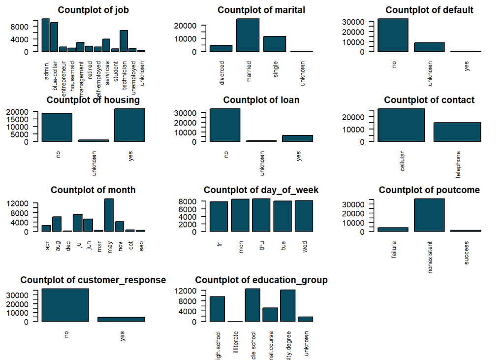

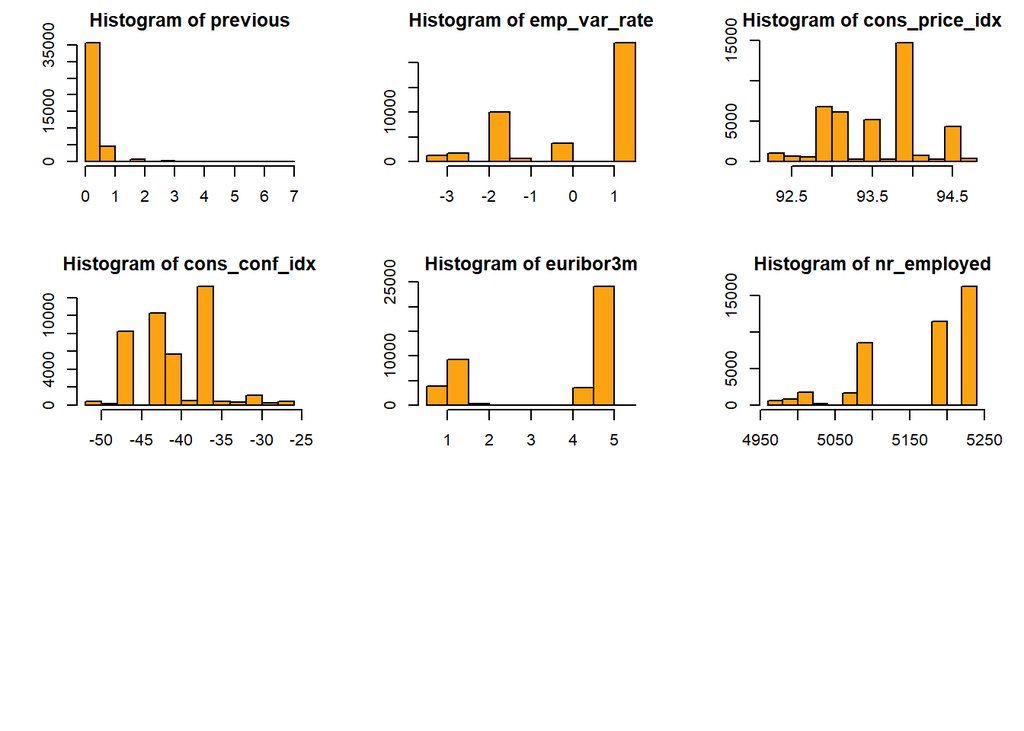

# 4 Statistical Modeling

Several classification modeling techniques, such as decision trees, logistic regression, random forest, and support vector machines, were used to predict whether or not a customer is likely to subscribe to a term deposit based on their characteristics. The primary focus was on the predictive capabilities of these models, followed by a comparative analysis to identify the best-performing model.

## 4.1 Handling imbalanced data with random oversampling technique

| Response | Frequency |
| --- | --- |
| no | 36548 |
| yes | 4640 |

The number of customers who declined for subscribing to the term deposit is significantly higher than the number of customers who responded positively. This imbalance can skew the performance of models, which misleads to high accuracy score for the majority class while fail to identify the minority class. A random oversampling technique was applied to handle the imbalanced data. In oversampling, instances from the minority class are duplicated to increase their representation in the dataset. This was done randomly until the number of instances in the minority class matches that of the majority class.

| Response | Frequency |
| --- | --- |
| no | 36548 |
| yes | 36513 |

We can see that after oversampling the data, the minority class is represented more equally with the majority class and the dataset becomes more balanced,

## 4.2 Transforming Numerical and Categorical Variables:

One-hot encoding was employed to convert categorical variables into numerical inputs, making them suitable for various machine-learning algorithms. The standardization technique was applied for numerical variables to transform the data, ensuring a mean of zero and a standard deviation of one.

## 4.3 Feauture Selection

The decision tree modeling was used for both feature selection of the data sets.The followings features were selected by the decision tree model as important features.

```
## important_features
##                      cons_conf_idx                     cons_price_idx
##                                  1                                  1
##                       emp_var_rate                          euribor3m
##                                  1                                  1
##                        nr_employed     previously_contacted_Contacted
##                                  1                                  1
## previously_contacted_Not.contacted
##                                  1
```

With the important features selected by the decision tree algorithm, the whole data set was then split into training and testing sets.

## 4.4 Evaluting Models

Model Performance Metrics

| Model | Accuracy | AUC | Precision | Recall | F1_Score |
| --- | --- | --- | --- | --- | --- |
| Decision Tree | 0.7394429 | 0.7493050 | 0.8663292 | 0.6911155 | 0.7688665 |
| Random Forest | 0.7551845 | 0.8111904 | 0.8915036 | 0.7006452 | 0.7846348 |
| SVM | 0.7271234 | 0.7711920 | 0.7273225 | 0.7272230 | 0.7272727 |
| Logistic Regression | 0.7271234 | 0.7728307 | 0.7267752 | 0.7274719 | 0.7271234 |

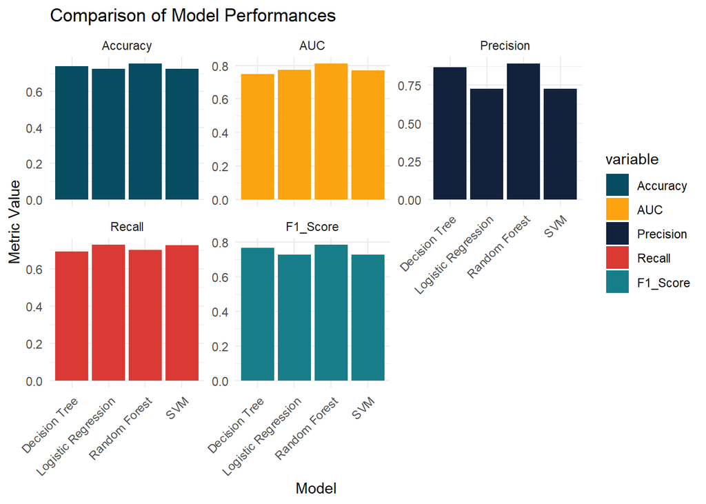

```
## [1] "AUC Decision Tree: 0.749305006951617"
```

```
## [1] "AUC Random Forest: 0.811190426109134"
```

```
## [1] "AUC SVM: 0.771191966665816"
```

```
## [1] "AUC Logistic Regression: 0.772830723999059"
```

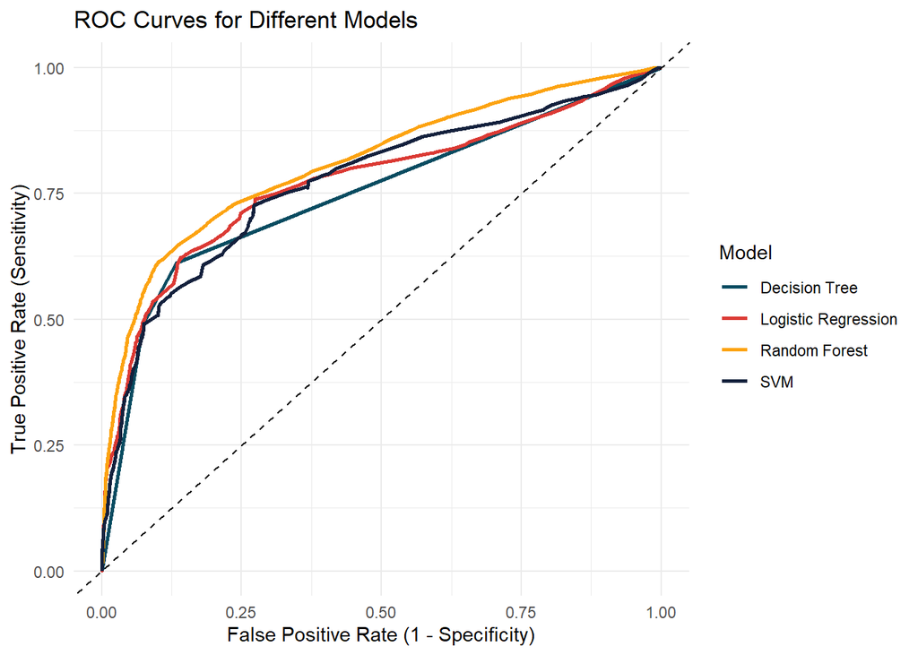

Although all the models’ performance was almost similar, overall, the Random Forest (yellow curve) demonstrates the highest area under the curve (AUC), meaning it consistently maintains a high True Positive Rate (TPR) with a low False Positive Rate (FPR) across various thresholds—indicates it is the most effective model for distinguishing between the classes.